# Identifying Outliers in Pregnancy Duration using R

Damola Mabogunje

2023-03-09

```r
# Hardcode the US repo for CRAN
r <-getOption("repos");
r["CRAN"] <- "http://cran.us.r-project.org";
options(repos = r);
rm(r);
```

## Introduction

This R Markdown document replicates some of the work done in chapter 9 of the Data Smart book by John W. Foreman which treats the technique of Outlier Detection using Excel.

Here, we’re going to be using R to achieve the same goal. Specifically, we’ll be looking at the case of Hadlum v. Hadlum and determining whether the Hadlum wife’s pregnancy was unlikely to be from the Hadlum husband.

Let’s load up the data from the PregnancyDuration csv.

```r
PregnancyDuration <- read.csv("data/PregnancyDuration.csv");
summary(PregnancyDuration); # Check Data
```

```
##  GestationDays
##  Min.   :240.0
##  1st Qu.:260.0
##  Median :267.0
##  Mean   :266.6
##  3rd Qu.:272.0
##  Max.   :349.0
```

```r
## Calculate the InterQuartile range (IQR)
PregnancyDuration.IQR <- IQR(PregnancyDuration$GestationDays);

## Calculate the Lower & Upper Tukey Fences
PregnancyDuration.LowerInnerFence <- 260 - 1.5*PregnancyDuration.IQR;
PregnancyDuration.UpperInnerFence <- 272 + 1.5*PregnancyDuration.IQR;
```

## Determine Outliers and Visualize them

Now that we have the Tukey Fences, we can identify outliers as those values that are greater or less than them respectively.

```r
OutlierIndexes <- which(PregnancyDuration$GestationDays > PregnancyDuration.UpperInnerFence);

OutlierValues <- PregnancyDuration$GestationDays[OutlierIndexes];
OutlierValues;
```

```
## [1] 349 292 295 291 297 303 293 296
```

But just looking at the figures isn’t all that exciting. Let’s visualize these numbers.

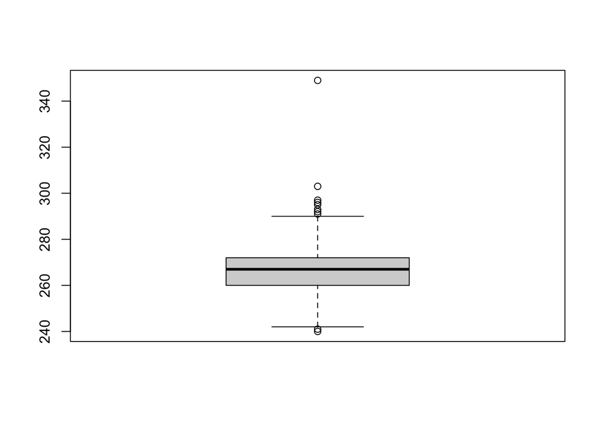

```r
boxplot(PregnancyDuration$GestationDays); # Uses the Inner Fences
```

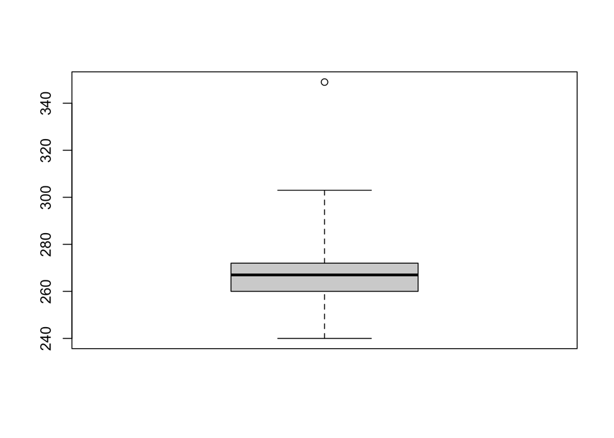

```r
boxplot(PregnancyDuration$GestationDays, range = 3) # Uses Outer Fences
```

## Conclusion

Boxploting with the outer Tukey Fences, we can clearly see that Mrs. Hadlum’s pregnancy duration was a significant outlier and unlikely to be Mr. Hadlum’s progeny. Below are the raw figures if you want to pull them out of the boxplot.

```r
# Tukey Fences & All
boxplot(PregnancyDuration$GestationDays, range = 3)$stats;
```

```
##      [,1]
## [1,]  240
## [2,]  260
## [3,]  267
## [4,]  272
## [5,]  303
```

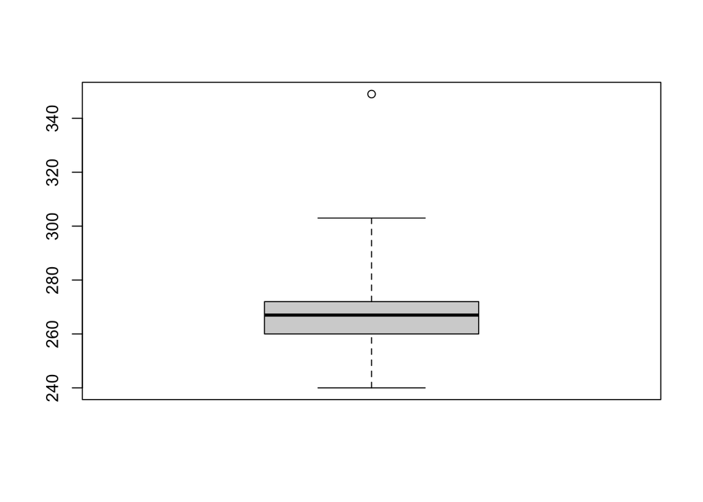

```
## [1] 349
```

```r
# Outliers based on the Outer Fence
boxplot(PregnancyDuration$GestationDays, range = 3)$out;
```